# NLP

Mao Wang

2021/12/28

```r
library(tidyverse)
library(tidytext)

library(SnowballC) # install.packages("SnowballC") # for stemming
library(udpipe) # install.packages("udpipe")
library(jiebaR)

# Mac畫圖設定中文字型
my_theme <- theme_bw() +
  theme(text = element_text(family = "STHeitiTC-Light"))
theme_set(my_theme)
```

## 1. 自然語言處理是什麼？

自然語言處理（Natural Language Processing, NLP）是透過程式語言來分析、理解、生成自然語言（人類用語）的一門學問。其應用範圍非常廣泛，舉凡如詞性標記、專有名詞辨識（named entity recognition, NER）、句法分析與聊天機器人等，都是自然語言處理的領域。**自然語言處理的效果良莠與否，與情緒分析一樣有賴於標記（annotate）資料的基礎建設**。

## 2. 詞幹提取（stemming）

首先，我們先從最基本的詞幹提取下手。詞幹提取顧名思義就是將文字的詞幹提取出來，所以詞幹常不會是一個完整的字，也有人認為詞幹提取其實也就是對文字資料進行降維（dimension reduction）。簡言之，原本許多相似的字，當轉換為dtm（document-term matrix）時，因為每個字仍是有差異，故會在不同欄位呈現。但當經過詞幹提取後，許多原本近似的字，就會簡化成同樣的詞幹，減少了許多欄位，可是仍保留一定的資料特徵。以下我們就直接來看看例子。

```r
# 可以使用的詞幹提取語言
SnowballC::getStemLanguages()
```

```
##  [1] "arabic"     "basque"     "catalan"    "danish"     "dutch"
##  [6] "english"    "finnish"    "french"     "german"     "greek"
## [11] "hindi"      "hungarian"  "indonesian" "irish"      "italian"
## [16] "lithuanian" "nepali"     "norwegian"  "porter"     "portuguese"
## [21] "romanian"   "russian"    "spanish"    "swedish"    "tamil"
## [26] "turkish"
```

```r
# 先建立一個相似字的vector
love_vec <- c("love", "loving", "lovingly", "loved", "lover", "lovely")

# 用data frame的方式來呈現轉換前後的差異
(love_stem_df <- tibble(origin = love_vec,
       stem = SnowballC::wordStem(words = love_vec)))
```

```
## # A tibble: 6 × 2
##   origin   stem
##   <chr>    <chr>
## 1 love     love
## 2 loving   love
## 3 lovingly lovingli
## 4 loved    love
## 5 lover    lover
## 6 lovely   love
```

原本是6個不同的相近字，在經過詞幹提取後，只剩下3種不同的詞幹，在轉換為dtm時，大幅減少資料欄位，使後續的各項計算更有效率；但相對地，在此種降維的過程中，會捨去一些資料的變異量。當資料非常大量時，詞幹提取幾乎已經是文字資料前處理的一項必備的標準步驟。接下來我們用Trump演說的資料來進行詞幹提取。

```r
# 將文字檔讀入，並轉換為data frame的格式來進行處理
trump_speech <- readr::read_lines("data/trumpspeeches.txt") %>%
        # 那個.代表將 %>% 前面的object放置在這個位置。
        tibble(text = .) %>%
        mutate(id = row_number())

trump_token <- trump_speech %>%
        tidytext::unnest_tokens(input = text, output = word)

# 沒有詞幹提取，直接轉換成dtm [56, 10097]
trump_token %>%
        count(id, word) %>%
        tidytext::cast_dtm(document = id, term = word, value = n)
```

```
## <<DocumentTermMatrix (documents: 56, terms: 10097)>>
## Non-/sparse entries: 46220/519212
## Sparsity           : 92%
## Maximal term length: 24
## Weighting          : term frequency (tf)
```

```r
# 經由詞幹提取，再轉換為dtm [56, 7878]
trump_token %>%
        mutate(word = SnowballC::wordStem(word)) %>%
        count(id, word) %>%
        tidytext::cast_dtm(document = id, term = word, value = n)
```

```
## <<DocumentTermMatrix (documents: 56, terms: 7878)>>
## Non-/sparse entries: 41551/399617
## Sparsity           : 91%
## Maximal term length: 22
## Weighting          : term frequency (tf)
```

可以看到term的欄位減少了至少1/5，對於要再將dtm繼續分析的各種文字模型而言，運算效率無疑是會提升，但犧牲的則是辭義的準確度，故亦有研究者（如tidytext作者）建議，諸如是跑主題模型時，是不用在前處理階段進行詞幹提取。（**但目前並無共識**）

## 3. 詞形還原（lemmatization）

誠如詞幹提取會喪失比較多的資訊量，而且完全丟棄了同詞幹但不同詞形的資訊，故另外有種方法是詞形還原，既可保留部分資訊，又可將資料進行簡化。但因為這涉及需要比較多的語料才能判斷，所以需要專門處理自然語言處理的套件。

我們這次主要會用到的套件是`udpipe`，UD是指Universal Dependencies，為的是建立一套全球語言共用的依存句法標示語料庫，以便於跨語言也能使用一致的語法標記，詳細資料請參見 [Universal Dependencies資料庫](https://universaldependencies.org/#download)。該資料庫目前已包括122種語言與217種 [結構樹資料庫](https://universaldependencies.org/introduction.html)（treebanks），光是英文就包含了12種結構樹資料庫，可依你要分析的資料來源選用不同的結構數資料庫。

```r
# 選擇你要分析的語言，下載已經標記好的資料
# ?udpipe_download_model
eng_model_data <- udpipe_download_model(language = "english-gum")
```

```
##  - This model has been trained on version 2.5 of data from https://universaldependencies.org
```

```
##  - The model is distributed under the CC-BY-SA-NC license: https://creativecommons.org/licenses/by-nc-sa/4.0
```

```
##  - Visit https://github.com/jwijffels/udpipe.models.ud.2.5 for model license details.
```

```
##  - For a list of all models and their licenses (most models you can download with this package have either a CC-BY-SA or a CC-BY-SA-NC license) read the documentation at ?udpipe_download_model. For building your own models: visit the documentation by typing vignette('udpipe-train', package = 'udp…
```

```r
names(eng_model_data)
```

```
## [1] "language"         "file_model"       "url"              "download_failed"
## [5] "download_message"
```

```r
# 其實這只是一個檔案路徑（用來顯示檔案下載後儲存的路徑）
eng_model_data$file_model
```

```
## [1] "/Users/Mao/Documents/09_teaching/11001_ntu_R_lang/03_code/english-gum-ud-2.5-191206.udpipe"
```

```r
# 讀取下載的語言資料檔
eng_model_gum <- udpipe_load_model(eng_model_data$file_model)
# 如果已經下載過語言資料，可以直接執行讀取資料就好
# eng_model_gum <- udpipe::udpipe_load_model(file = "english-gum-ud-2.5-191206.udpipe")
```

因為詞形還原涉及前後文的判斷才能作到，故先前用的`love_vec`在這邊沒有辦法呈現詞形還原的效果。我們將續用Trump演講的資料來演練。

```r
# 進行各種標記，包括詞形還原（語法簡單，但要花較多時間運算）
# ?udpipe_annotate
# 因為標註時間較長，只用前10筆資料演示
trump_anno_gum <- udpipe_annotate(eng_model_gum,
                              # x需要輸入df裡面的一個欄位
                              x = trump_speech$text[1:10],
                              doc_id = trump_speech$id[1:10],
                              # 顯示進度
                              trace = TRUE)
```

```
## 2021-12-28 02:21:30 Annotating text fragment 1/10
## 2021-12-28 02:21:33 Annotating text fragment 2/10
## 2021-12-28 02:21:34 Annotating text fragment 3/10
## 2021-12-28 02:21:36 Annotating text fragment 4/10
## 2021-12-28 02:21:37 Annotating text fragment 5/10
## 2021-12-28 02:21:39 Annotating text fragment 6/10
## 2021-12-28 02:21:40 Annotating text fragment 7/10
## 2021-12-28 02:21:42 Annotating text fragment 8/10
## 2021-12-28 02:21:45 Annotating text fragment 9/10
## 2021-12-28 02:21:50 Annotating text fragment 10/10
```

```r
typeof(trump_anno_gum)
```

```
## [1] "list"
```

```r
names(trump_anno_gum)
```

```
## [1] "x"      "conllu" "errors"
```

```r
# trump_anno是一個list物件，將其轉成data frame
(trump_anno_df_gum <- as_tibble(trump_anno_gum))
```

```
## # A tibble: 52,527 × 14
##    doc_id paragraph_id sentence_id sentence     token_id token lemma upos  xpos
##    <chr>         <int>       <int> <chr>        <chr>    <chr> <chr> <chr> <chr>
##  1 1                 1           1 Trump: Wow.  1        Trump Trump NOUN  NN
##  2 1                 1           1 Trump: Wow.  2        :     :     PUNCT :
##  3 1                 1           1 Trump: Wow.  3        Wow   Wow   NOUN  NN
##  4 1                 1           1 Trump: Wow.  4        .     .     PUNCT .
##  5 1                 1           2 Whoa.        1        Whoa  Whoa  NOUN  NN
##  6 1                 1           2 Whoa.        2        .     .     PUNCT .
##  7 1                 1           3 That is som… 1        That  that  PRON  DT
##  8 1                 1           3 That is som… 2        is    be    AUX   VBZ
##  9 1                 1           3 That is som… 3        some  some  DET   DT
## 10 1                 1           3 That is som… 4        group group NOUN  NN
## # … with 52,517 more rows, and 5 more variables: feats <chr>,
## #   head_token_id <chr>, dep_rel <chr>, deps <chr>, misc <chr>
```

```r
# 比較一下token數與lemma數
trump_anno_df_gum %>%
        summarize(
                token_n = dplyr::n_distinct(token),
                lemma_n = dplyr::n_distinct(lemma))
```

```
## # A tibble: 1 × 2
##   token_n lemma_n
##     <int>   <int>
## 1    5668    4638
```

```r
# 來看看高頻的動詞都怎麼還原
trump_anno_df_gum %>%
        filter(upos == "VERB") %>%
        count(token, lemma, sort = TRUE)
```

```
## # A tibble: 1,543 × 3
##    token    lemma        n
##    <chr>    <chr>    <int>
##  1 have     have       343
##  2 going    go         269
##  3 said     say        177
##  4 know     know       163
##  5 do       do         128
##  6 want     want        96
##  7 think    think       95
##  8 applause applause    90
##  9 get      get         87
## 10 say      say         75
## # … with 1,533 more rows
```

詞形還原會還原語境脈絡下的詞形，如**因時態、單複數、變形（比較級、最高級）等因素而改變的字**。

## 4. 詞性標記

因為中文語料不需要考慮詞幹提取與詞形還原，所以剛剛都只有介紹英文語料的處理方式，接下來要做的詞性標記，則英文、中文語料都可以處理，我們將用到剛剛介紹的`udpipe`與之前介紹過的`jiebaR`，來完成這項工作。

### 4.1 英文詞性標記

每種不同的標記方式都會有不同的代碼來表示詞性，有興趣的同學可以參考 [Universal POS tags](https://universaldependencies.org/u/pos/all.html#universal-pos-tags)，找出你有興趣要分析的詞性代碼。其實剛剛在做`udpipe_annotate`時，就一併把詞性也標記好了，所以我們才能篩選出動詞詞形還原前與後的比較。接下來來看看詞性標記還有什麼應用。

```r
# Trump喜歡說哪種詞性的字
trump_anno_df_gum %>%
        count(upos, sort = TRUE) %>%
        mutate(total = sum(n),
               perc = n / total,
               total = NULL)
```

```
## # A tibble: 17 × 3
##    upos      n     perc
##    <chr> <int>    <dbl>
##  1 NOUN   7606 0.145
##  2 VERB   6652 0.127
##  3 PUNCT  6616 0.126
##  4 PRON   6338 0.121
##  5 ADP    4317 0.0822
##  6 AUX    3773 0.0718
##  7 DET    3479 0.0662
##  8 PROPN  3204 0.0610
##  9 ADJ    2906 0.0553
## 10 ADV    2370 0.0451
## 11 CCONJ  1800 0.0343
## 12 PART   1717 0.0327
## 13 SCONJ  1072 0.0204
## 14 NUM     517 0.00984
## 15 INTJ    135 0.00257
## 16 SYM      16 0.000305
## 17 X         9 0.000171
```

```r
# 接連出現的名詞與形容詞
# ?udpipe::cooccurrence
cooc <- udpipe::cooccurrence(
        # 詞形還原後的lemma當成輸入資料
        trump_anno_df_gum$lemma,
        # 限定詞性為名詞與形容詞
        relevant = trump_anno_df_gum$upos %in% c("NOUN", "ADJ"),
        # skipgram代表前後相鄰字的範圍（window）
        skipgram = 1)

head(cooc, 10)
```

```
##       term1     term2 cooc
## 1   foreign    policy   30
## 2   Islamic terrorism   17
## 3  American    people   12
## 4     other   country   11
## 5       law     order   11
## 6     trade      deal   10
## 7   special  interest   10
## 8       lot    people   10
## 9     other    people    9
## 10    other       day    9
```

## 練習一

請試試下載不同的英文結構樹資料庫，看看Trump常講的動詞有沒有差異？

```r
eng_model_data <- udpipe_download_model(language = "__________")

# 讀取下載的語言資料檔
eng_model <- udpipe_load_model(__________________)

trump_anno <- udpipe_annotate(eng_model,
                              x = trump_speech$text[1:10],
                              doc_id = trump_speech$id[1:10],
                              trace = TRUE)

# trump_anno是一個list物件，將其轉成data frame
(trump_anno_df <- as_tibble(trump_anno))

# 比較一下token數與lemma數
trump_anno_df %>%
        summarize(
                token_n = n_distinct(token),
                lemma_n = n_distinct(lemma))

trump_anno_df_ewt %>%
        summarize(
                token_n = n_distinct(token),
                lemma_n = n_distinct(lemma))

# 來看看高頻的動詞都怎麼還原
trump_anno_df %>%
        filter(upos == "_____") %>%
        count(token, lemma, sort = TRUE)

# 比較先前使用不同treebank的結果
trump_anno_df_gum %>%
        filter(upos == "VERB") %>%
        count(token, lemma, sort = TRUE)
```

### 4.2 中文詞性標記

中文詞性標記的方法，其實在斷詞時就可以一併完成，先用簡單的例子讓大家瞭解是怎麼進行的，首先我們用jiebaR來做詞性標記。

```r
# 建立斷詞引擎，但需附加詞性標註功能
seg_engine_tag <- jiebaR::worker(bylines = TRUE, type = "tag")

# 先從簡單的vector格式來試試
toy_vec <- c("我很難過", "我家門前有條水溝很難過")
toy_result <- segment(toy_vec, jiebar = seg_engine_tag)
map(toy_result, names)
```

```
## [[1]]
## [1] "r"  "zg" "v"
##
## [[2]]
## [1] "r"  "s"  "x"  "n"  "zg" "v"
```

```r
# 回到我們最常使用的data frame格式來操作
toyexample <- tibble(sentence = c("我很難過", "我家門前有條水溝很難過"))

(toy_example_tag <- toyexample %>%
        mutate(token = segment(sentence, jieba = seg_engine_tag),
               pos = map(token, names)) %>%
        unnest(c(token, pos))
)
```

```
## # A tibble: 9 × 3
##   sentence               token pos
##   <chr>                  <chr> <chr>
## 1 我很難過               我    r
## 2 我很難過               很    zg
## 3 我很難過               難過  v
## 4 我家門前有條水溝很難過 我家  r
## 5 我家門前有條水溝很難過 門前  s
## 6 我家門前有條水溝很難過 有條  x
## 7 我家門前有條水溝很難過 水溝  n
## 8 我家門前有條水溝很難過 很    zg
## 9 我家門前有條水溝很難過 難過  v
```

做法上與斷詞非常雷同，只是要在斷詞引擎上另外加上`type = "tag"`的功能。後續的操作十分相似，差異點在於此時list column除了是斷詞結果的vector，其vector還是有名字屬性（named vector，這邊是指詞性）。詳細的詞性代碼，可以參考 [此連結](https://gist.github.com/hankcs/d7dbe79dde3f85b423e4)。接下來我們運用審計部新聞發布資料，實際來看標註後的資料是什麼樣子。

```r
# 讀入資料，並將審計部資料轉為nao
load("data/nao.RData")
nao <- data_all
glimpse(nao)
```

```
## Rows: 119
## Columns: 4
## $ title    <chr> "審計部試行金融區塊鏈函證服務平臺", "審計部2019年國際審計技術…
## $ date     <chr> "2019-04-01 ", "2019-03-11 ", "2019-03-01 ", "2019-03-01 ", "…
## $ link     <chr> "http://www.audit.gov.tw/p/405-1000-5375,c104.php?Lang=zh-tw"…
## $ fulltext <chr> "外部函證係審計機關重要審計程序及蒐集審計證據的方法之一，審計機關長期以來皆投入相當人力及時間辦理紙本詢證函作業，期提升審計品質及價值。民國(下同)105年財金資訊股份有限公司與台灣主要大型銀行共同成立金融區塊鏈研究暨應用發展委員會，歷時2年多探索與實作驗證區塊鏈技術，推出全球首創「金融區塊鏈函證服務平臺」。審計部為肆應上開金融科技新趨勢，自107年下半年主動研議導入，將於本(108)年4月1日正式試行，並與國內各會計師事務所同步。希各銀行及各被審核機關共同協助審計機關試行金融科技之電子化函證作業服務，共創無紙化及高效能的數位化審計函證新頁。", "審計…
```

```r
# 進行斷詞，
(nao_tag <- nao %>%
        mutate(id = row_number(),
               # 斷詞方式與之前教的做法一樣。
               token = segment(fulltext, jieba = seg_engine_tag),
               # 每一個觀察值皆取出該vector的names
               pos = map(token, names),
               date = lubridate::ymd(date)) %>%
        select(id, date, token, pos) %>%
        # 現在有兩個list columns
        unnest(cols = c(token, pos)))
```

```
## # A tibble: 22,295 × 4
##       id date       token pos
##    <int> <date>     <chr> <chr>
##  1     1 2019-04-01 外部  f
##  2     1 2019-04-01 函證  x
##  3     1 2019-04-01 係    zg
##  4     1 2019-04-01 審計  v
##  5     1 2019-04-01 機關  n
##  6     1 2019-04-01 重要  a
##  7     1 2019-04-01 審計  v
##  8     1 2019-04-01 程序  n
##  9     1 2019-04-01 及    c
## 10     1 2019-04-01 蒐集  v
## # … with 22,285 more rows
```

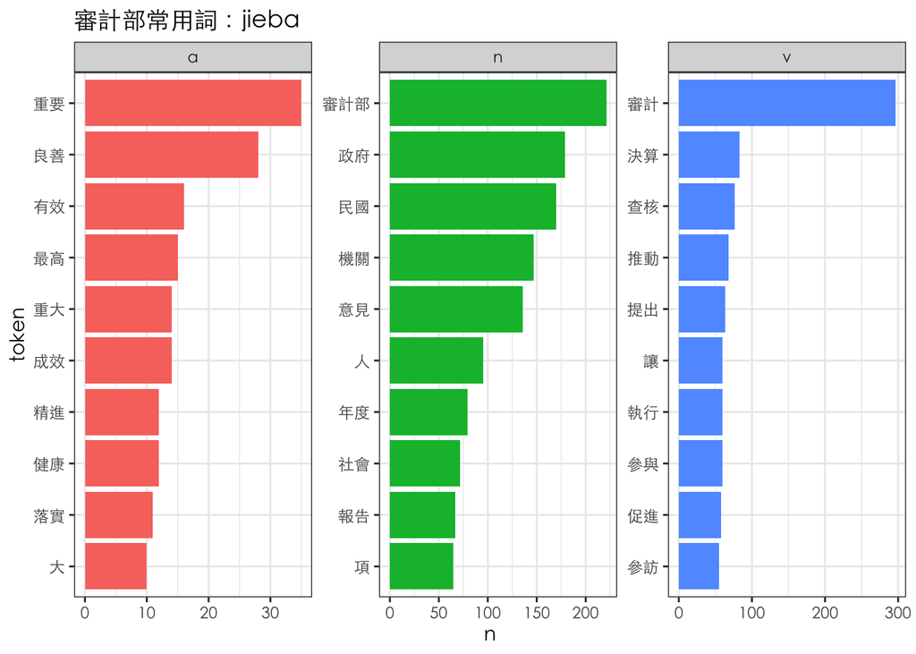

```r
(jieba_plot <- nao_tag %>%
        # 選取詞性為動詞、形容詞、名詞的資料
        filter(pos %in% c("v", "a", "n")) %>%
        count(pos, token) %>%
        # 選出三種詞性的前10常用詞
        group_by(pos) %>%
        top_n(10, wt = n) %>%
        ungroup() %>%
        # 畫成圖表示
        ggplot(aes(x = reorder(token, n), y = n, fill = pos)) +
        geom_col(show.legend = FALSE) +
        facet_wrap(~ pos, scales = "free") +
        coord_flip() +
        labs(x = "token", title = "審計部常用詞：jieba"))
```

除了用jiebaR可以進行詞性標記外，也可以使用前面介紹的`udpipe`來做詞性標記，但我們一樣要先下載要分析語言的資料，才能夠進行後續的標記任務。

```r
# 拿前面udpipe的model來試試（預設會下載在工作目錄）
ch_model_data <- udpipe::udpipe_download_model(language = "chinese-gsd")
```

```
##  - This model has been trained on version 2.5 of data from https://universaldependencies.org
```

```
##  - The model is distributed under the CC-BY-SA-NC license: https://creativecommons.org/licenses/by-nc-sa/4.0
```

```
##  - Visit https://github.com/jwijffels/udpipe.models.ud.2.5 for model license details.
```

```
##  - For a list of all models and their licenses (most models you can download with this package have either a CC-BY-SA or a CC-BY-SA-NC license) read the documentation at ?udpipe_download_model. For building your own models: visit the documentation by typing vignette('udpipe-train', package = 'udp…
```

```r
# 看下載的資料裡有什麼
names(ch_model_data) # 裡面有說明「語言」、「下載的檔案」、「下載檔案的網頁位置」
```

```
## [1] "language"         "file_model"       "url"              "download_failed"
## [5] "download_message"
```

```r
# 取出使用資料的
ch_model <- udpipe::udpipe_load_model(file = ch_model_data$file_model)

# 如果已經下載過語言資料，可以直接執行讀取資料就好
# ch_model <- udpipe::udpipe_load_model(file = "chinese-gsd-ud-2.5-191206.udpipe")

# ?udpipe_annotate
# 實際將資料進行標記
nao_result <- udpipe_annotate(object = ch_model,
                              x = nao$fulltext,
                              trace = TRUE) %>%
        as_tibble()
```

[output not shown]

[output cut: 64 more lines]

[output not shown]

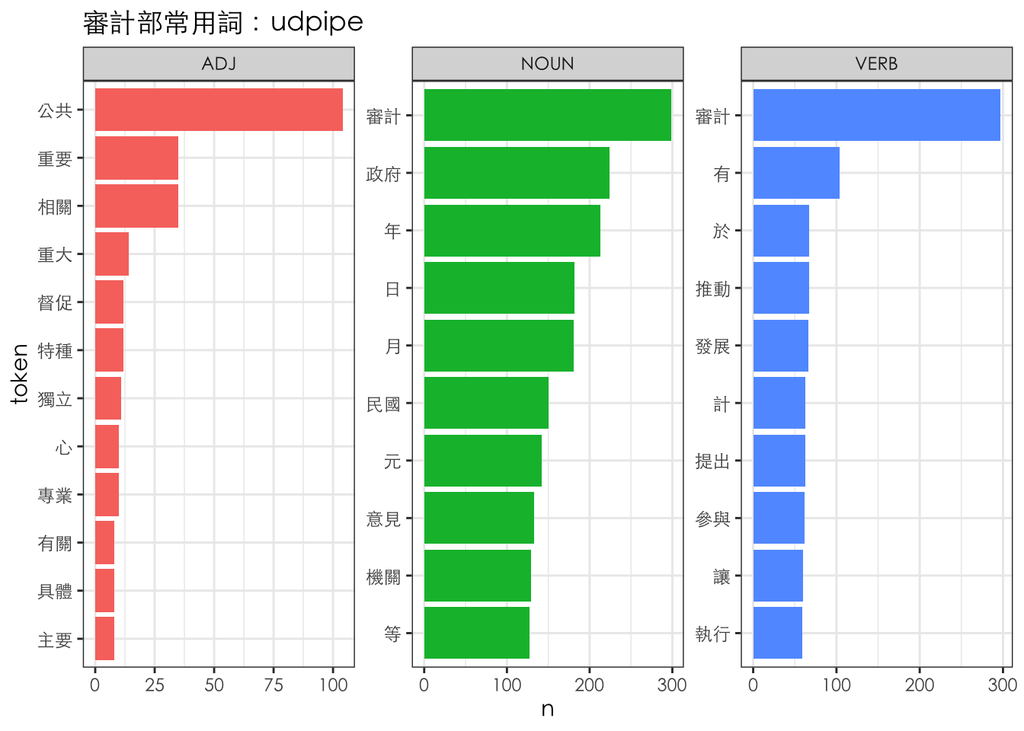

```r
# 與之前畫圖的語法一樣
(udpipe_plot <- nao_result %>%
        # 不同的套件對於詞性註記的代碼不同，請注意！
        filter(upos %in% c("VERB", "ADJ", "NOUN")) %>%
        count(upos, token) %>%
        group_by(upos) %>%
        top_n(10, wt = n) %>%
        ungroup() %>%
        ggplot(aes(x = reorder(token, n), y = n, fill = upos)) +
        geom_col(show.legend = FALSE) +
        facet_wrap(~ upos, scales = "free") +
        coord_flip() +
        labs(x = "token", title = "審計部常用詞：udpipe"))
```

我們分別使用了jiebaR與udpipe兩個不同套件的訓練資料來分析審計部的新聞發布資料，現在可以把兩張圖畫在一起，看看兩者的差異。

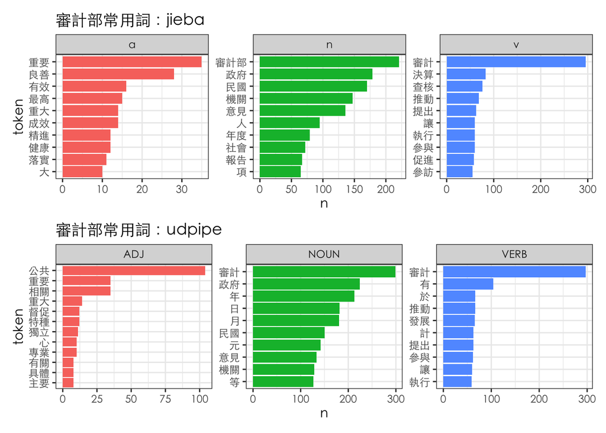

```r
library(patchwork) # install.packages("patchwork")
jieba_plot + udpipe_plot + patchwork::plot_layout(ncol = 1)
```

## 練習二

一樣執行前面用jiebaR與udpipe斷詞與詞性標註，但這次把斷詞後結果為單字的情況去掉，再畫一次圖，看看結果有什麼改變？

```r
(jieba_plot <- nao_tag %>%
        # 選取詞性為動詞、形容詞、名詞的資料
        filter(pos %in% _______________,
               str_length(token) >= 2) %>%
        count(pos, token) %>%
        # 選出三種詞性的前10常用詞
        group_by(pos) %>%
        top_n(10, wt = n) %>%
        ungroup() %>%
        # 畫成圖表示
        ggplot(aes(x = reorder(token, n), y = n, fill = pos)) +
        geom_col(show.legend = FALSE) +
        facet_wrap(~ pos, scales = "free") +
        coord_flip() +
        labs(x = "token", title = "審計部常用詞：jieba"))

(udpipe_plot <- nao_result %>%
        # 不同的套件對於詞性註記的代碼不同，請注意！
        filter(upos %in% _______________,
               str_length(token) >= 2) %>%
        count(upos, token) %>%
        group_by(upos) %>%
        top_n(10, wt = n) %>%
        ungroup() %>%
        ggplot(aes(x = reorder(token, n), y = n, fill = upos)) +
        geom_col(show.legend = FALSE) +
        facet_wrap(~ upos, scales = "free") +
        coord_flip() +
        labs(x = "token", title = "審計部常用詞：udpipe"))

jieba_plot + udpipe_plot + patchwork::plot_layout(ncol = 1)
```

## 其他參考資料

- 中研院資訊科學研究所馬偉雲助研究員對於 [NLP](http://research.sinica.edu.tw/nlp-natural-language-processing-chinese-knowledge-information/)的介紹。